# Did Level of Prior Medical Care Correlate with Health Outcomes in the Covid-19 Pandemic

Sam Kevy, 917191015

## Introduction

This report utilized the WHO database tracking all cases of Covid-19 in every country through out the world. This dataset was combined with data tracking the average number of times an individual recieved medical care (ie saw a doctor) per year for 41 countries. In addition each countries GDP (Gross Domestic Product) was included in the data set. This dataset was used to answer the following question of interest: Did the the level of healthcare citizens recieved prior to the Covid-19 pandemic (as measured by number of Dr. Visits), in addition to the GDP of said country have an effect on the number of cumulative deaths per capita in the year 2020 that a country suffered?

#### WHO COVID-19 DataSet

```r
library(tidyverse)
```

```r
covid <- read_csv("https://covid19.who.int/WHO-COVID-19-global-data.csv")
```

```r
head(covid)
```

A tibble: 6 × 8

| Date_reported <date> | Country_code <chr> | Country <chr> | WHO_region <chr> | New_cases <dbl> | Cumulative_cases <dbl> | New_deaths <dbl> | Cumulative_deaths <dbl> |
| --- | --- | --- | --- | --- | --- | --- | --- |
| 2020-01-03 | AF | Afghanistan | EMRO | 0 | 0 | 0 | 0 |
| 2020-01-04 | AF | Afghanistan | EMRO | 0 | 0 | 0 | 0 |
| 2020-01-05 | AF | Afghanistan | EMRO | 0 | 0 | 0 | 0 |
| 2020-01-06 | AF | Afghanistan | EMRO | 0 | 0 | 0 | 0 |
| 2020-01-07 | AF | Afghanistan | EMRO | 0 | 0 | 0 | 0 |
| 2020-01-08 | AF | Afghanistan | EMRO | 0 | 0 | 0 | 0 |

```r
length(unique(covid$Country))
```

237

#### Combined Data Set

Code used to create dataset

```r
# isolating 2020 covid data
covid2 = covid[covid$Date_reported < "2020-12-31", ]
```

```r
y=tapply(covid2$Cumulative_deaths, covid2$Country_code, max)
```

```r
# cumulative deaths via country code
Codedeaths = as.data.frame.table(y)

code_deaths = Codedeaths %>%
  rename(
    code = Var1,
     deaths = Freq
    )
```

```r
x=tapply(covid2$Cumulative_deaths, covid2$Country, max)
```

```r
# cumulative deaths via country
Countrydeaths = as.data.frame.table(x)

country_deaths = Countrydeaths %>%
  rename(
    country = Var1,
     deaths = Freq
    )
```

```r
head(country_deaths)
```

A data.frame: 6 × 2

|  | country <fct> | deaths <dbl> |
| --- | --- | --- |
| 1 | Afghanistan | 2189 |
| 2 | Albania | 1170 |
| 3 | Algeria | 2736 |
| 4 | American Samoa | 0 |
| 5 | Andorra | 84 |
| 6 | Angola | 399 |

```r
#install country codes
install.packages("countrycode")
```

```r
library("countrycode")
```

```r
Drvis = read.csv('./ProjectData/Drvisists.csv')
```

```r
#trim Dr Visist

drvis = cbind(Drvis$LOCATION, Drvis$TIME, Drvis$Value)
head(drvis)
```

A matrix: 6 × 3 of type chr

| AUS | 1960 | 2.7 |
| --- | --- | --- |
| AUS | 1961 | 2.8 |
| AUS | 1962 | 2.9 |
| AUS | 1963 | 2.9 |
| AUS | 1964 | 2.9 |
| AUS | 1965 | 2.8 |

```r
visit = data.frame(drvis)

drvis = visit %>%
  rename(
    country = X1,
     year = X2,
      value = X3
    )
```

```r
visits<-drvis[!(drvis$year > 2019),]
```

```r
length(unique(visits$country))
```

41

```r
length(unique(drvis$country))
length(unique(Drvis$LOCATION))
length(unique(country_deaths$country))
```

41

41

237

```r
# selecting the most up to date medical info

x=tapply(visits$year, visits$country, max)
vis = as.data.frame.table(x)
```

```r
medical = vis %>%
  rename(
    country = Var1,
     year = Freq,
    )
dim(medical)
```

1. 41

2. 2

```r
# final data set
medvis =merge(x=medical,y=visits,by= c("country", 'year'))
dim(medvis)
```

1. 41

2. 3

```r
# transfering to country code
df1= code_deaths
df2= medvis
```

```r
df1$iso3c   <- countrycode(df1$code, origin = "iso2c", destination = "iso3c")
df2$iso3c   <- countrycode(df2$country, origin = "iso3c", destination = "iso3c")
 combo        <- merge(df1,df2,id="iso3c")
combo$country <- countrycode(combo$iso3c, origin = "iso3c", destination = "country.name")
```

```r
dim(combo)
```

1. 41

2. 6

```r
combo$value = as.numeric(combo$value)
```

```r
# Medical Data V Deaths
pop = read.csv('./ProjectData/Pop.csv')
```

```r
head(pop)
```

A data.frame: 6 × 65

|  | Country.Name <chr> | Country.Code <chr> | Indicator.Name <chr> | Indicator.Code <chr> | X1960 <dbl> | X1961 <dbl> | X1962 <dbl> | X1963 <dbl> | X1964 <dbl> | X1965 <dbl> | ⋯ | X2011 <dbl> | X2012 <dbl> | X2013 <dbl> | X2014 <dbl> | X2015 <dbl> | X2016 <dbl> | X2017 <dbl> | X2018 <dbl> | X2019 <dbl> | X2020 <dbl> |
| --- | --- | --- | --- | --- | --- | --- | --- | --- | --- | --- | --- | --- | --- | --- | --- | --- | --- | --- | --- | --- | --- |
| 1 | Aruba | ABW | Population, total | SP.POP.TOTL | 54208 | 55434 | 56234 | 56699 | 57029 | 57357 | ⋯ | 102050 | 102565 | 103165 | 103776 | 104339 | 104865 | 105361 | 105846 | 106310 | 106766 |
| 2 | Africa Eastern and Southern | AFE | Population, total | SP.POP.TOTL | 130836765 | 134159786 | 137614644 | 141202036 | 144920186 | 148769974 | ⋯ | 532760424 | 547482863 | 562601578 | 578075373 | 593871847 | 609978946 | 626392880 | 643090131 | 660046272 | 677243299 |
| 3 | Afghanistan | AFG | Population, total | SP.POP.TOTL | 8996967 | 9169406 | 9351442 | 9543200 | 9744772 | 9956318 | ⋯ | 30117411 | 31161378 | 32269592 | 33370804 | 34413603 | 35383028 | 36296111 | 37171922 | 38041757 | 38928341 |
| 4 | Africa Western and Central | AFW | Population, total | SP.POP.TOTL | 96396419 | 98407221 | 100506960 | 102691339 | 104953470 | 107289875 | ⋯ | 360285439 | 370243017 | 380437896 | 390882979 | 401586651 | 412551299 | 423769930 | 435229381 | 446911598 | 458803476 |
| 5 | Angola | AGO | Population, total | SP.POP.TOTL | 5454938 | 5531451 | 5608499 | 5679409 | 5734995 | 5770573 | ⋯ | 24220660 | 25107925 | 26015786 | 26941773 | 27884380 | 28842482 | 29816769 | 30809787 | 31825299 | 32866268 |
| 6 | Albania | ALB | Population, total | SP.POP.TOTL | 1608800 | 1659800 | 1711319 | 1762621 | 1814135 | 1864791 | ⋯ | 2905195 | 2900401 | 2895092 | 2889104 | 2880703 | 2876101 | 2873457 | 2866376 | 2854191 | 2837743 |

```r
# trim data
Pop = cbind(pop$Country.Code, pop$X2020)
```

```r
z = data.frame(Pop)
```

```r
poped = z %>%
  rename(
    iso3c = X1,
     Population = X2,
    )
```

```r
poped$Population = as.numeric(poped$Population)
```

```r
fullset = merge(combo,poped,id="iso3c")
```

```r
fullset$deaths_per_capita = fullset$deaths/fullset$Population
```

```r
e = tapply(covid2$Cumulative_cases, covid2$Country_code, max)
```

```r
# cumulative cases via code
codecase = as.data.frame.table(e)

Cases = codecase %>%
  rename(
    code = Var1,
     cases = Freq
    )
```

```r
fullset = merge(Cases,fullset,id="code")
```

```r
fullset$cases_per_capita = fullset$cases/fullset$Population
```

```r
Gdp = read.csv('./ProjectData/Gdp.csv')
```

```r
head(Gdp)
```

A data.frame: 6 × 65

|  | Country.Name <chr> | Country.Code <chr> | Indicator.Name <chr> | Indicator.Code <chr> | X1960 <dbl> | X1961 <dbl> | X1962 <dbl> | X1963 <dbl> | X1964 <dbl> | X1965 <dbl> | ⋯ | X2011 <dbl> | X2012 <dbl> | X2013 <dbl> | X2014 <dbl> | X2015 <dbl> | X2016 <dbl> | X2017 <dbl> | X2018 <dbl> | X2019 <dbl> | X2020 <dbl> |
| --- | --- | --- | --- | --- | --- | --- | --- | --- | --- | --- | --- | --- | --- | --- | --- | --- | --- | --- | --- | --- | --- |
| 1 | Aruba | ABW | GDP (current US$) | NY.GDP.MKTP.CD | NA | NA | NA | NA | NA | NA | ⋯ | 2549720670 | 2534636872 | 2727849721 | 2790849162 | 2962905028 | 2983636872 | 3092430168 | 3.202189e+09 | NA | NA |
| 2 | Africa Eastern and Southern | AFE | GDP (current US$) | NY.GDP.MKTP.CD | 19299444453 | 19709535909 | 21478715486 | 25715008783 | 23510800233 | 26791601696 | ⋯ | 942710850898 | 949849051927 | 963560356978 | 983748641614 | 918647122202 | 872023488531 | 984255550008 | 1.011723e+12 | 1.008375e+12 | 918815487643 |
| 3 | Afghanistan | AFG | GDP (current US$) | NY.GDP.MKTP.CD | 537777811 | 548888896 | 546666678 | 751111191 | 800000044 | 1006666638 | ⋯ | 17805113119 | 19907317066 | 20146404996 | 20497126770 | 19134211764 | 18116562465 | 18753469630 | 1.805323e+10 | 1.879945e+10 | 20116137326 |
| 4 | Africa Western and Central | AFW | GDP (current US$) | NY.GDP.MKTP.CD | 10404280784 | 11128050589 | 11943353288 | 12676515454 | 13838577015 | 14862472886 | ⋯ | 670962551548 | 727571396578 | 820787588844 | 851487150652 | 760729687147 | 690543020916 | 683741574626 | 7.416916e+11 | 7.945725e+11 | 784587603323 |
| 5 | Angola | AGO | GDP (current US$) | NY.GDP.MKTP.CD | NA | NA | NA | NA | NA | NA | ⋯ | 111789686464 | 128052853643 | 136709862831 | 145712200313 | 116193649124 | 101123851090 | 122123822334 | 1.013532e+11 | 8.941719e+10 | 58375976293 |
| 6 | Albania | ALB | GDP (current US$) | NY.GDP.MKTP.CD | NA | NA | NA | NA | NA | NA | ⋯ | 12890764531 | 12319830437 | 12776220507 | 13228147516 | 11386850130 | 11861199831 | 13019689337 | 1.515643e+10 | 1.540024e+10 | 14887629268 |

```r
t = cbind(Gdp$Country.Code, Gdp$X2020)
```

```r
h = data.frame(t)
GDP = h %>%
  rename(
    iso3c = X1,
     GDP = X2,
    )
```

```r
fullset = merge(GDP,fullset,id="iso3c")
```

```r
fullset$GDP = as.numeric(fullset$GDP)
```

```r
fullset$GDP_per_capita = fullset$GDP/fullset$Population
```

```r
fullset$Region = 1
```

```r
fullset$Region[fullset$code == "MX"] = 2
fullset$Region[fullset$code == "BR"] = 3
fullset$Region[fullset$code == "CL"] = 3
fullset$Region[fullset$code == "CR"] = 3
fullset$Region[fullset$code == "IL"] = 5
fullset$Region[fullset$code == "ZA"] = 6
fullset$Region[fullset$code == "JP"] = 4
fullset$Region[fullset$code == "KR"] = 4
fullset$Region[fullset$code == "CA"] = 2
fullset$Region[fullset$code == "US"] = 2
fullset$Region[fullset$code == "NZ"] = 7
```

Region Codes: 1- Europe 2- North America 3- Latin America 4-Asia 5-Western Asia and North Africa 6- Africa

## Final Dataset

The Main Variables of Interest are Value- representing medical visits per year, Deaths per Capita, and GDP

```r
fullset
```

A data.frame: 41 × 13

| iso3c <chr> | GDP <dbl> | code <fct> | cases <dbl> | deaths <dbl> | country <chr> | year <chr> | value <dbl> | Population <dbl> | deaths_per_capita <dbl> | cases_per_capita <dbl> | GDP_per_capita <dbl> | Region <dbl> |
| --- | --- | --- | --- | --- | --- | --- | --- | --- | --- | --- | --- | --- |
| AUS | 1.327836e+12 | AU | 28350 | 909 | Australia | 2019 | 7.3 | 25687041 | 3.538749e-05 | 0.0011036694 | 51692.843 | 1 |
| AUT | 4.332585e+11 | AT | 353080 | 6256 | Austria | 2019 | 6.6 | 8917205 | 7.015651e-04 | 0.0395953665 | 48586.801 | 1 |
| BEL | 5.218613e+11 | BE | 646437 | 19684 | Belgium | 2019 | 7.3 | 11555997 | 1.703358e-03 | 0.0559395265 | 45159.348 | 1 |
| BRA | 1.444733e+12 | BR | 7504833 | 191570 | Brazil | 2013 | 2.8 | 212559409 | 9.012539e-04 | 0.0353069903 | 6796.845 | 3 |
| CAN | 1.644037e+12 | CA | 559064 | 15222 | Canada | 2019 | 6.6 | 38005238 | 4.005237e-04 | 0.0147101828 | 43258.176 | 2 |
| CHE | 7.522480e+11 | CH | 446959 | 7425 | Switzerland | 2017 | 4.3 | 8636896 | 8.596838e-04 | 0.0517499574 | 87097.036 | 1 |
| CHL | 2.529400e+11 | CL | 603986 | 16488 | Chile | 2019 | 2.9 | 19116209 | 8.625141e-04 | 0.0315954905 | 13231.704 | 3 |
| COL | 2.714376e+11 | CO | 1603807 | 42374 | Colombia | 2019 | 2.6 | 50882884 | 8.327751e-04 | 0.0315195774 | 5334.556 | 1 |
| CRI | 6.184690e+10 | CR | 165762 | 2144 | Costa Rica | 2019 | 2.3 | 5094114 | 4.208779e-04 | 0.0325399078 | 12140.854 | 3 |
| CZE | 2.453495e+11 | CZ | 702411 | 11737 | Czechia | 2019 | 8.2 | 10698896 | 1.097029e-03 | 0.0656526617 | 22932.225 | 1 |
| DEU | 3.846414e+12 | DE | 1687185 | 32107 | Germany | 2019 | 9.8 | 83240525 | 3.857136e-04 | 0.0202687934 | 46208.429 | 1 |
| DNK | 3.560849e+11 | DK | 162573 | 1284 | Denmark | 2019 | 4.0 | 5831404 | 2.201871e-04 | 0.0278788779 | 61063.316 | 1 |
| ESP | 1.281485e+12 | ES | 1947543 | 54144 | Spain | 2017 | 7.3 | 47351567 | 1.143447e-03 | 0.0411294308 | 27063.194 | 1 |
| EST | 3.065029e+10 | EE | 27256 | 226 | Estonia | 2019 | 5.5 | 1331057 | 1.697899e-04 | 0.0204769593 | 23027.027 | 1 |
| FIN | 2.697513e+11 | FI | 36168 | 588 | Finland | 2019 | 4.4 | 5530719 | 1.063153e-04 | 0.0065394752 | 48773.281 | 1 |
| FRA | 2.630318e+12 | FR | 2563604 | 63701 | France | 2018 | 5.9 | 67391582 | 9.452368e-04 | 0.0380404188 | 39030.360 | 1 |
| GBR | 2.764198e+12 | GB | 2480981 | 74452 | United Kingdom | 2009 | 5.0 | 67215293 | 1.107665e-03 | 0.0369109601 | 41124.535 | 1 |
| GRC | 1.888352e+11 | GR | 137599 | 4730 | Greece | 2019 | 3.2 | 10715549 | 4.414146e-04 | 0.0128410593 | 17622.541 | 1 |
| HUN | 1.558084e+11 | HU | 319543 | 9429 | Hungary | 2019 | 10.7 | 9749763 | 9.671004e-04 | 0.0327744377 | 15980.741 | 1 |
| IRL | 4.258890e+11 | IE | 88397 | 2269 | Ireland | 2019 | 5.8 | 4994724 | 4.542794e-04 | 0.0176980750 | 85267.765 | 1 |
| ISL | 2.171808e+10 | IS | 5747 | 29 | Iceland | 2014 | 5.9 | 366425 | 7.914307e-05 | 0.0156839735 | 59270.180 | 1 |
| ISR | 4.071007e+11 | IL | 413864 | 3321 | Israel | 2019 | 8.2 | 9216900 | 3.603164e-04 | 0.0449027330 | 44168.944 | 5 |
| ITA | 1.888709e+12 | IT | 2067487 | 73029 | Italy | 2019 | 10.4 | 59554023 | 1.226265e-03 | 0.0347161601 | 31714.221 | 1 |
| JPN | 5.057759e+12 | JP | 226596 | 3349 | Japan | 2018 | 12.5 | 125836021 | 2.661400e-05 | 0.0018007245 | 40193.252 | 4 |
| KOR | 1.637896e+12 | KR | 59755 | 879 | South Korea | 2019 | 17.2 | 51780579 | 1.697548e-05 | 0.0011540041 | 31631.469 | 4 |
| LTU | 5.654696e+10 | LT | 141754 | 1747 | Lithuania | 2019 | 9.5 | 2794700 | 6.251118e-04 | 0.0507224389 | 20233.641 | 1 |
| LUX | 7.335313e+10 | LU | 46009 | 487 | Luxembourg | 2019 | 5.5 | 632275 | 7.702345e-04 | 0.0727673876 | 116014.602 | 1 |
| LVA | 3.370732e+10 | LV | 37676 | 603 | Latvia | 2019 | 6.1 | 1901548 | 3.171101e-04 | 0.0198133310 | 17726.253 | 1 |
| MEX | 1.073916e+12 | MX | 1479968 | 146652 | Mexico | 2019 | 2.3 | 128932753 | 1.137430e-03 | 0.0114786039 | 8329.271 | 2 |
| NLD | 9.138654e+11 | NL | 776425 | 11185 | Netherlands | 2019 | 8.8 | 17441139 | 6.412999e-04 | 0.0445168747 | 52397.117 | 1 |
| NOR | 3.625223e+11 | NO | 49144 | 429 | Norway | 2019 | 4.4 | 5379475 | 7.974756e-05 | 0.0091354640 | 67389.912 | 1 |
| NZL | 2.107008e+11 | NZ | 1796 | 25 | New Zealand | 2017 | 3.8 | 5084300 | 4.917098e-06 | 0.0003532443 | 41441.467 | 7 |
| POL | 5.966244e+11 | PL | 1284624 | 28109 | Poland | 2019 | 7.7 | 37950802 | 7.406695e-04 | 0.0338497194 | 15720.995 | 1 |
| PRT | 2.285392e+11 | PT | 400002 | 6751 | Portugal | 2012 | 4.1 | 10305564 | 6.550830e-04 | 0.0388141784 | 22176.297 | 1 |
| RUS | 1.483498e+12 | RU | 3131550 | 56426 | Russia | 2019 | 9.9 | 144104080 | 3.915642e-04 | 0.0217311682 | 10294.627 | 1 |
| SVK | 1.051726e+11 | SK | 173228 | 2065 | Slovakia | 2019 | 11.1 | 5458827 | 3.782864e-04 | 0.0317335574 | 19266.514 | 1 |
| SVN | 5.358961e+10 | SI | 117403 | 2924 | Slovenia | 2019 | 6.7 | 2100126 | 1.392297e-03 | 0.0559028363 | 25517.331 | 1 |
| SWE | 5.412201e+11 | SE | 428428 | 9577 | Sweden | 2019 | 2.6 | 10353442 | 9.250064e-04 | 0.0413802482 | 52274.409 | 1 |
| TUR | 7.199548e+11 | TR | 2178580 | 20388 | Turkey | 2019 | 9.8 | 84339067 | 2.417385e-04 | 0.0258312082 | 8536.433 | 1 |
| USA | 2.089375e+13 | US | 19372111 | 348480 | United States | 2011 | 4.0 | 329484123 | 1.057653e-03 | 0.0587952792 | 63413.514 | 2 |
| ZAF | 3.354421e+11 | ZA | 1021451 | 27568 | South Africa | 2012 | 2.5 | 59308690 | 4.648223e-04 | 0.0172226195 | 5655.868 | 6 |

```r
head(fullset)
```

A data.frame: 6 × 13

|  | iso3c <chr> | GDP <dbl> | code <fct> | cases <dbl> | deaths <dbl> | country <chr> | year <chr> | value <dbl> | Population <dbl> | deaths_per_capita <dbl> | cases_per_capita <dbl> | GDP_per_capita <dbl> | Region <dbl> |
| --- | --- | --- | --- | --- | --- | --- | --- | --- | --- | --- | --- | --- | --- |
| 1 | AUS | 1.327836e+12 | AU | 28350 | 909 | Australia | 2019 | 7.3 | 25687041 | 3.538749e-05 | 0.001103669 | 51692.843 | 1 |
| 2 | AUT | 4.332585e+11 | AT | 353080 | 6256 | Austria | 2019 | 6.6 | 8917205 | 7.015651e-04 | 0.039595366 | 48586.801 | 1 |
| 3 | BEL | 5.218613e+11 | BE | 646437 | 19684 | Belgium | 2019 | 7.3 | 11555997 | 1.703358e-03 | 0.055939526 | 45159.348 | 1 |
| 4 | BRA | 1.444733e+12 | BR | 7504833 | 191570 | Brazil | 2013 | 2.8 | 212559409 | 9.012539e-04 | 0.035306990 | 6796.845 | 3 |
| 5 | CAN | 1.644037e+12 | CA | 559064 | 15222 | Canada | 2019 | 6.6 | 38005238 | 4.005237e-04 | 0.014710183 | 43258.176 | 2 |
| 6 | CHE | 7.522480e+11 | CH | 446959 | 7425 | Switzerland | 2017 | 4.3 | 8636896 | 8.596838e-04 | 0.051749957 | 87097.036 | 1 |

```r
library(maps)
```

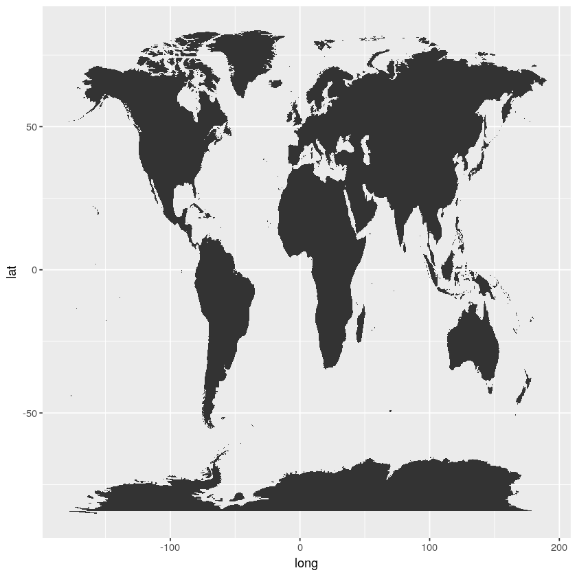

```r
world <- map_data("world");
worldplot <- ggplot() +
  geom_polygon(data = world, aes(x=long, y = lat, group = group))
worldplot
```

```r
fig.map  <- ggplot() +
  geom_polygon(data = fullset, aes(x=long$world, y = lat$world, group = group,fill=value)) +
  coord_fixed(1.3)
fig.map
```

[output not shown]

## Background

Covid-19 is a highly transmissable virus which originated in December of 2019 in Wuhan China. It quickly spread around the globe, infecting around 420 million people in just over 2 years, killing 5.86 million. The elderly, and those with pre-existing conditions and auto-immune issues have been most at risk of death, as well as other significant ailements.

## Summary Statistics

```r
head(fullset)
```

A data.frame: 6 × 13

|  | iso3c <chr> | GDP <dbl> | code <fct> | cases <dbl> | deaths <dbl> | country <chr> | year <chr> | value <dbl> | Population <dbl> | deaths_per_capita <dbl> | cases_per_capita <dbl> | GDP_per_capita <dbl> | Region <dbl> |
| --- | --- | --- | --- | --- | --- | --- | --- | --- | --- | --- | --- | --- | --- |
| 1 | AUS | 1.327836e+12 | AU | 28350 | 909 | Australia | 2019 | 7.3 | 25687041 | 3.538749e-05 | 0.001103669 | 51692.843 | 1 |
| 2 | AUT | 4.332585e+11 | AT | 353080 | 6256 | Austria | 2019 | 6.6 | 8917205 | 7.015651e-04 | 0.039595366 | 48586.801 | 1 |
| 3 | BEL | 5.218613e+11 | BE | 646437 | 19684 | Belgium | 2019 | 7.3 | 11555997 | 1.703358e-03 | 0.055939526 | 45159.348 | 1 |
| 4 | BRA | 1.444733e+12 | BR | 7504833 | 191570 | Brazil | 2013 | 2.8 | 212559409 | 9.012539e-04 | 0.035306990 | 6796.845 | 3 |
| 5 | CAN | 1.644037e+12 | CA | 559064 | 15222 | Canada | 2019 | 6.6 | 38005238 | 4.005237e-04 | 0.014710183 | 43258.176 | 2 |
| 6 | CHE | 7.522480e+11 | CH | 446959 | 7425 | Switzerland | 2017 | 4.3 | 8636896 | 8.596838e-04 | 0.051749957 | 87097.036 | 1 |

use world map to visualize info -doctor vis -cumulative cases -gdp

- acount for Region
- interaction with value

```r
sum(fullset$cases)
sum(fullset$deaths)
sum(fullset$deaths)/sum(fullset$cases)
```

55479136

1300762

0.023445967147001

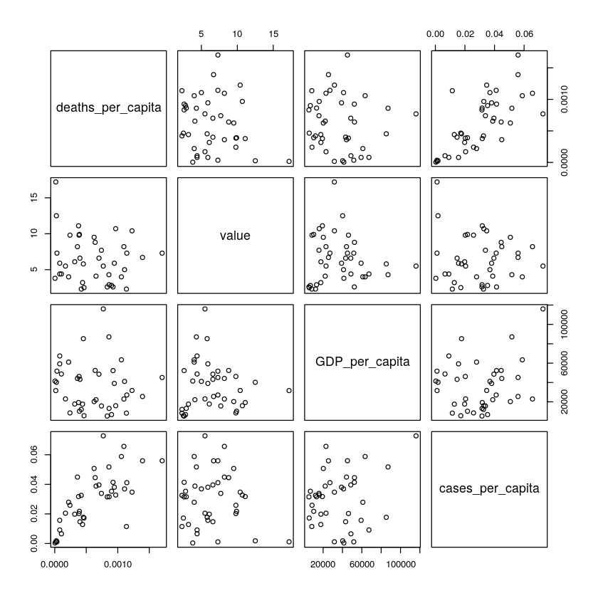

```r
plot(fullset[,c("deaths_per_capita",'value','GDP_per_capita','cases_per_capita')])
```

## Inferential Analysis

To analyze the question of interest, we'll linear regression following the model yi=β0+x1*β1+x2*β2+ β3*X1*X2 +ϵi where B0 represents the intercept, B1 the coefficient of X1 number of medical visits, B2 the coefficient of X2 GDP and B3 the coefficient of the interaction of X1 and X2, the relationship between number of medical appointments and country GDP.

Need to add: Assumptions for model Is this the best model?

This model allows us to complete a F-hypothesis testing, which allows us to reject any linear correlation between deaths per capita, number of medical visits and GDP.

## Fitting Model

Once fitted, the linear regression model shows that there is no linear correlation between deaths per capita, number of medical visits and GDP. Following the null hypothesis that B1=B2=B3=0 and the alternative hypothesis that B1,B2, and B3 do not equal zero , we fail to reject the null hypothesis, as the p-value are all greater than the selected significane level of 0.05.

-try transformation on response and predictor - higher order term, exclude interaction maybe, boxcox transformation on response

- remove outliers in residual plot

```r
deathmodel = lm(deaths_per_capita ~ value*GDP_per_capita , data=fullset)
```

```r
intmodel = lm(deaths_per_capita ~ value*GDP_per_capita -1 , data=fullset)
```

```r
summary(intmodel)
```

```
Call:
lm(formula = deaths_per_capita ~ value * GDP_per_capita - 1,
    data = fullset)

Residuals:
       Min         1Q     Median         3Q        Max
-6.534e-04 -3.952e-04  4.704e-05  3.787e-04  1.216e-03

Coefficients:
                       Estimate Std. Error t value Pr(>|t|)
value                 1.023e-04  2.280e-05   4.487  6.5e-05 ***
GDP_per_capita        1.930e-08  5.047e-09   3.825 0.000473 ***
value:GDP_per_capita -3.433e-09  1.089e-09  -3.152 0.003157 **
---
Signif. codes:  0 ‘***’ 0.001 ‘**’ 0.01 ‘*’ 0.05 ‘.’ 0.1 ‘ ’ 1

Residual standard error: 0.0004715 on 38 degrees of freedom
Multiple R-squared:  0.6299,	Adjusted R-squared:  0.6007
F-statistic: 21.56 on 3 and 38 DF,  p-value: 2.535e-08
```

```r
fullset$fatality = fullset$deaths/fullset$cases
```

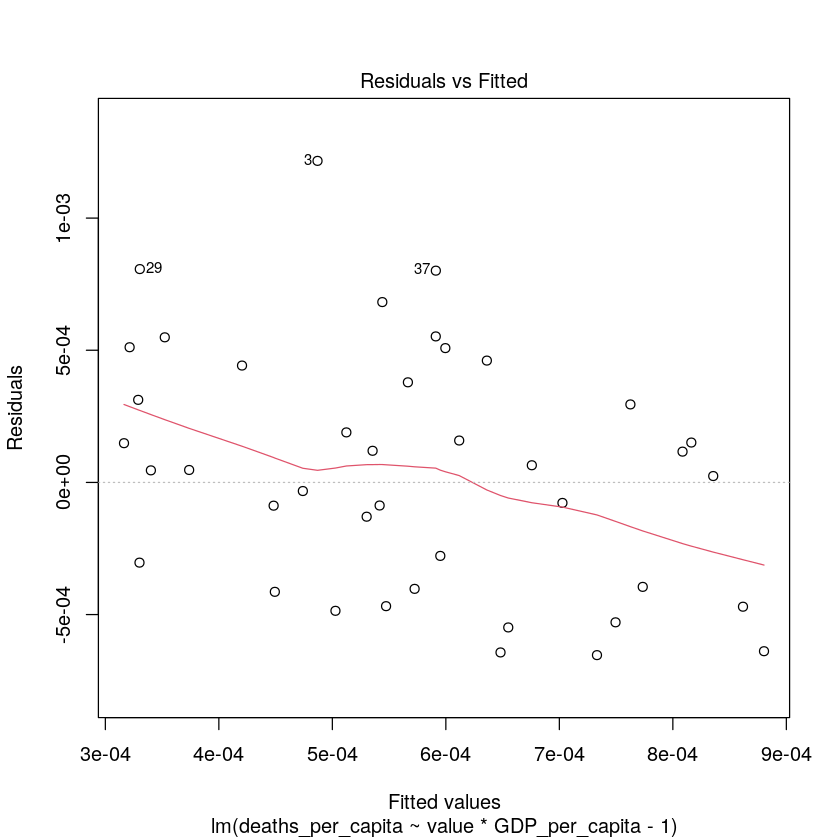

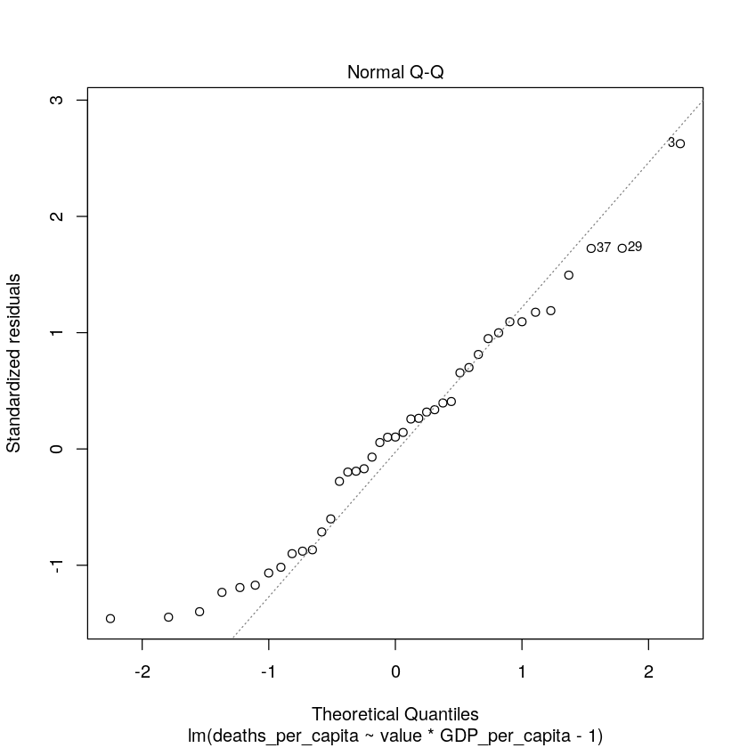

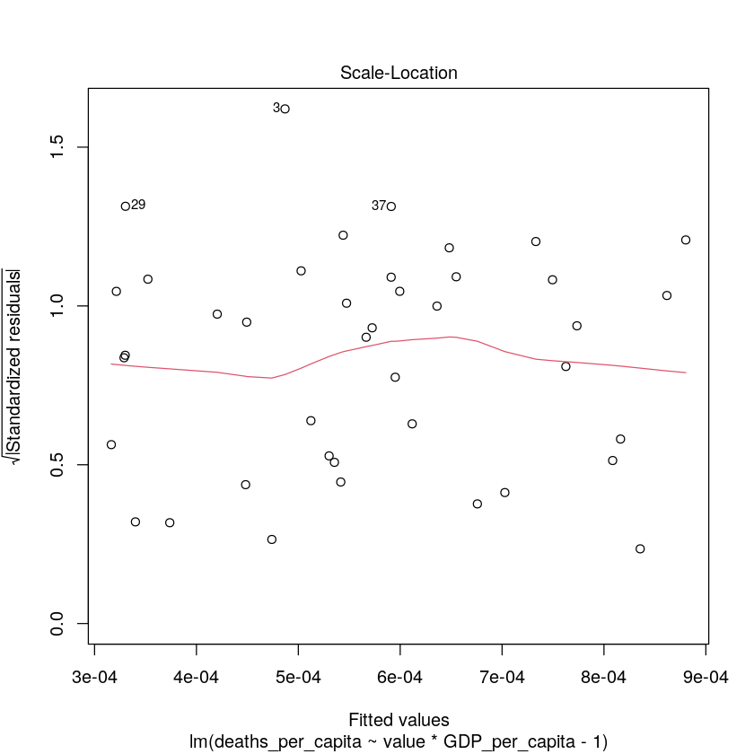

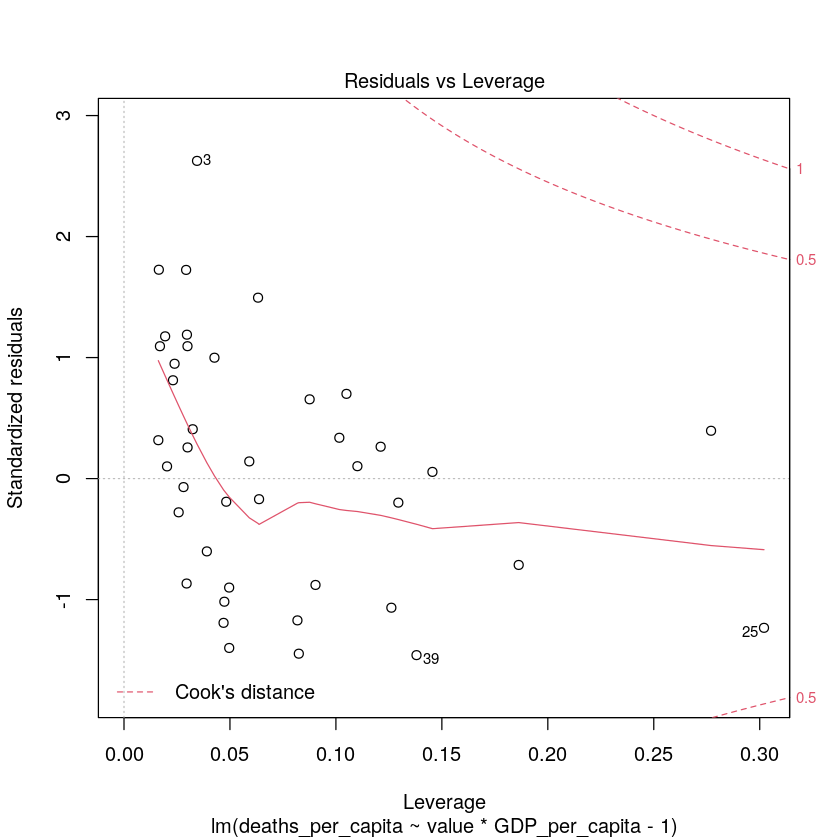

```r
plot(intmodel)
```

```r
summary(deathmodel)
```

```
Call:
lm(formula = deaths_per_capita ~ value * GDP_per_capita, data = fullset)

Residuals:
       Min         1Q     Median         3Q        Max
-0.0006739 -0.0003457 -0.0000413  0.0002732  0.0011303

Coefficients:
                       Estimate Std. Error t value Pr(>|t|)
(Intercept)           7.829e-04  2.753e-04   2.844  0.00722 **
value                -1.385e-05  4.590e-05  -0.302  0.76458
GDP_per_capita        2.686e-11  8.211e-09   0.003  0.99741
value:GDP_per_capita -3.335e-10  1.479e-09  -0.226  0.82283
---
Signif. codes:  0 ‘***’ 0.001 ‘**’ 0.01 ‘*’ 0.05 ‘.’ 0.1 ‘ ’ 1

Residual standard error: 0.0004328 on 37 degrees of freedom
Multiple R-squared:  0.04082,	Adjusted R-squared:  -0.03695
F-statistic: 0.5249 on 3 and 37 DF,  p-value: 0.6679
```

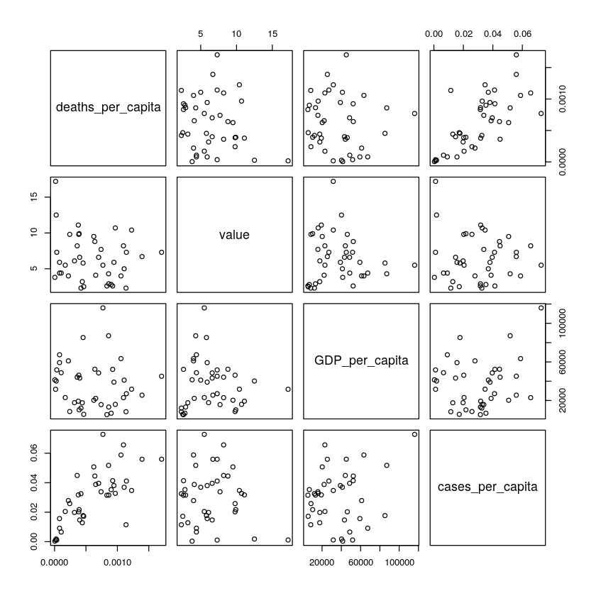

```r
plot(fullset[,c("deaths_per_capita",'value','GDP_per_capita','cases_per_capita')])
```

```r
install.packages('ggplot2')
```

```r
library('ggplot2')
```

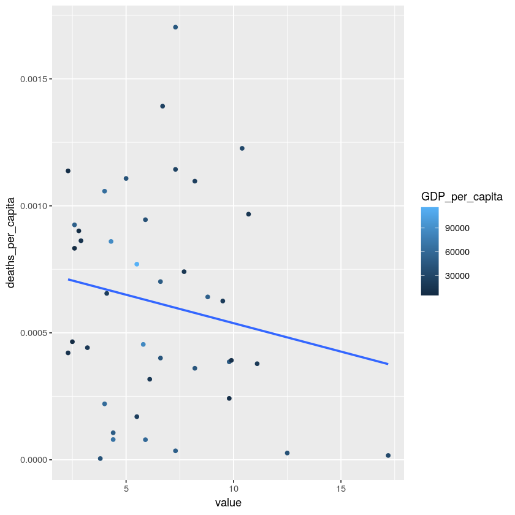

```r
ggplot(fullset,aes(y=deaths_per_capita,x=value,color=GDP_per_capita))+geom_point()+stat_smooth(method="lm",se=FALSE)
```

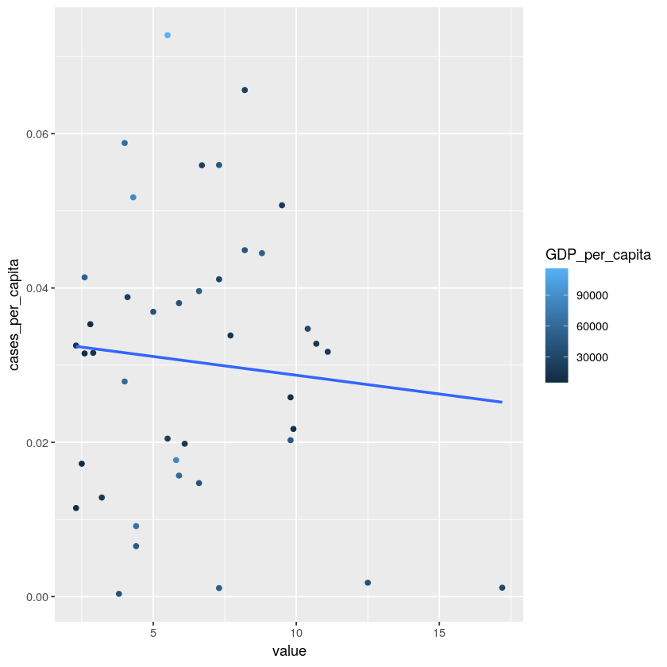

```r
ggplot(fullset,aes(y=cases_per_capita,x=value,color=GDP_per_capita))+geom_point()+stat_smooth(method="lm",se=FALSE)
```

```r
casemodel = lm(cases_per_capita ~ value*GDP_per_capita, data = fullset)
summary(casemodel)
```

```
Call:
lm(formula = cases_per_capita ~ value * GDP_per_capita, data = fullset)

Residuals:
      Min        1Q    Median        3Q       Max
-0.033951 -0.012952  0.001783  0.009364  0.036349

Coefficients:
                       Estimate Std. Error t value Pr(>|t|)
(Intercept)           1.757e-02  1.156e-02   1.520    0.137
value                 1.658e-03  1.928e-03   0.860    0.395
GDP_per_capita        5.393e-07  3.448e-07   1.564    0.126
value:GDP_per_capita -7.571e-08  6.211e-08  -1.219    0.231

Residual standard error: 0.01818 on 37 degrees of freedom
Multiple R-squared:  0.08232,	Adjusted R-squared:  0.007916
F-statistic: 1.106 on 3 and 37 DF,  p-value: 0.3588
```

As this model only uses data from 41 countries, linear modeling is difficult. Here we remove the intercept so that the linear correlation only acounts for the main relationships between per capita cases, doctors visits, and GDP.

```r
intcase =  lm(cases_per_capita ~ value*GDP_per_capita -1, data = fullset)
summary(intcase)
```

```
Call:
lm(formula = cases_per_capita ~ value * GDP_per_capita - 1, data = fullset)

Residuals:
      Min        1Q    Median        3Q       Max
-0.033262 -0.013056  0.003114  0.014983  0.035700

Coefficients:
                       Estimate Std. Error t value Pr(>|t|)
value                 4.266e-03  8.942e-04   4.771 2.71e-05 ***
GDP_per_capita        9.721e-07  1.979e-07   4.912 1.75e-05 ***
value:GDP_per_capita -1.453e-07  4.270e-08  -3.402  0.00159 **
---
Signif. codes:  0 ‘***’ 0.001 ‘**’ 0.01 ‘*’ 0.05 ‘.’ 0.1 ‘ ’ 1

Residual standard error: 0.01849 on 38 degrees of freedom
Multiple R-squared:  0.7464,	Adjusted R-squared:  0.7264
F-statistic: 37.29 on 3 and 38 DF,  p-value: 2.081e-11
```

```r
nonicase =  lm(cases_per_capita ~ value + GDP_per_capita -1, data = fullset)
summary(nonicase)
```

```
Call:
lm(formula = cases_per_capita ~ value + GDP_per_capita - 1, data = fullset)

Residuals:
      Min        1Q    Median        3Q       Max
-0.044777 -0.003418  0.007117  0.017431  0.040741

Coefficients:
                Estimate Std. Error t value Pr(>|t|)
value          1.964e-03  6.593e-04   2.980  0.00495 **
GDP_per_capita 3.838e-07  1.086e-07   3.535  0.00107 **
---
Signif. codes:  0 ‘***’ 0.001 ‘**’ 0.01 ‘*’ 0.05 ‘.’ 0.1 ‘ ’ 1

Residual standard error: 0.02084 on 39 degrees of freedom
Multiple R-squared:  0.6692,	Adjusted R-squared:  0.6522
F-statistic: 39.45 on 2 and 39 DF,  p-value: 4.282e-10
```

```r
single =  lm(cases_per_capita ~ value, data = fullset)
summary(single)
```

```
Call:
lm(formula = cases_per_capita ~ value, data = fullset)

Residuals:
      Min        1Q    Median        3Q       Max
-0.031351 -0.015000  0.000107  0.009251  0.041889

Coefficients:
              Estimate Std. Error t value Pr(>|t|)
(Intercept)  0.0335508  0.0064566   5.196 6.73e-06 ***
value       -0.0004859  0.0008927  -0.544    0.589
---
Signif. codes:  0 ‘***’ 0.001 ‘**’ 0.01 ‘*’ 0.05 ‘.’ 0.1 ‘ ’ 1

Residual standard error: 0.01841 on 39 degrees of freedom
Multiple R-squared:  0.007539,	Adjusted R-squared:  -0.01791
F-statistic: 0.2963 on 1 and 39 DF,  p-value: 0.5893
```

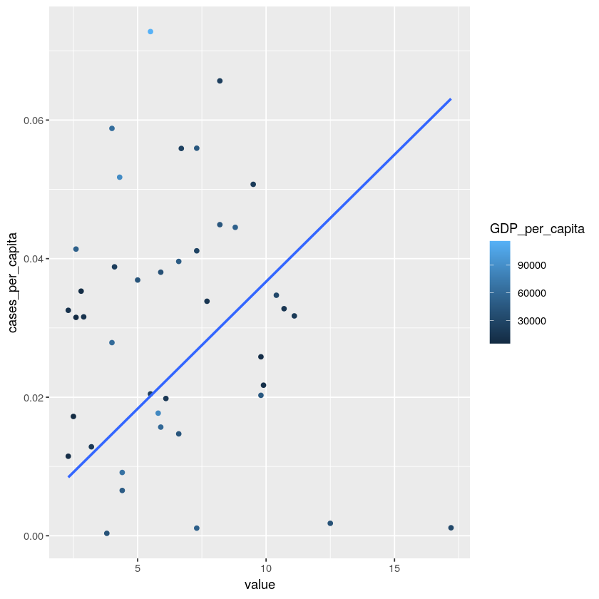

```r
ggplot(fullset,aes(y=cases_per_capita,x=value,color=GDP_per_capita))+geom_point()+stat_smooth(method="lm", formula = y~x -1, se=FALSE)
```

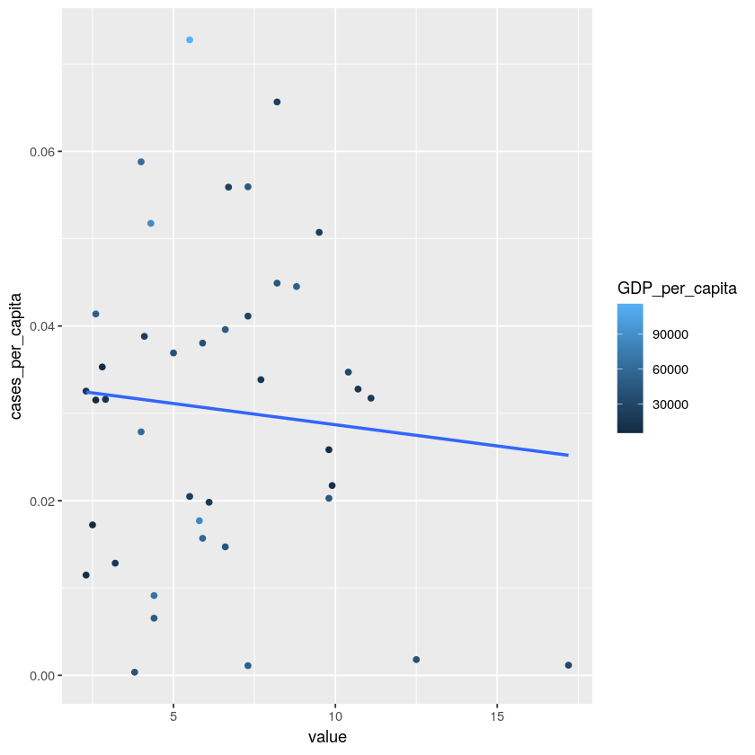

```r
ggplot(fullset,aes(y=cases_per_capita,x=value,color=GDP_per_capita))+geom_point()+stat_smooth(method="lm", formula = y~x, se=FALSE)
```

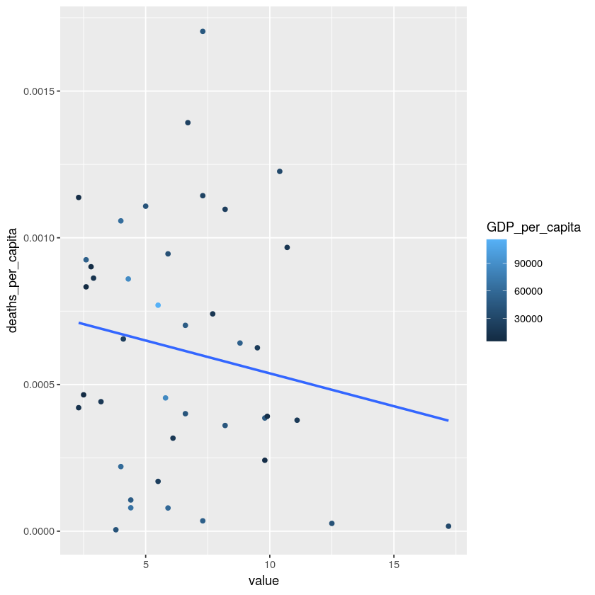

```r
ggplot(fullset,aes(y=deaths_per_capita,x=value,color=GDP_per_capita))+geom_point()+stat_smooth(method="lm", formula = y~x, se=FALSE)
```

-try case mortality rate

check if deaths is significant

case-studies on why influential cases

color for region

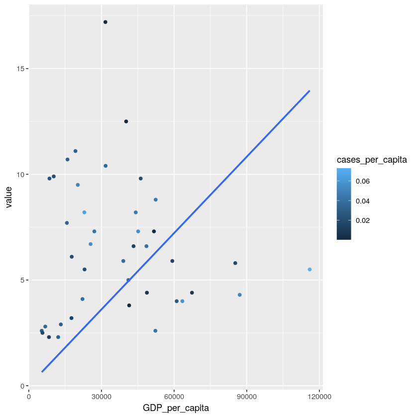

```r
ggplot(fullset,aes(y=value,x=GDP_per_capita,color=cases_per_capita))+geom_point()+stat_smooth(method="lm", formula = y~x -1, se=FALSE)
```

### Box Cox Transformation

```r
install.packages('MASS')
```

```r
library('MASS')
```

0.707070707070707

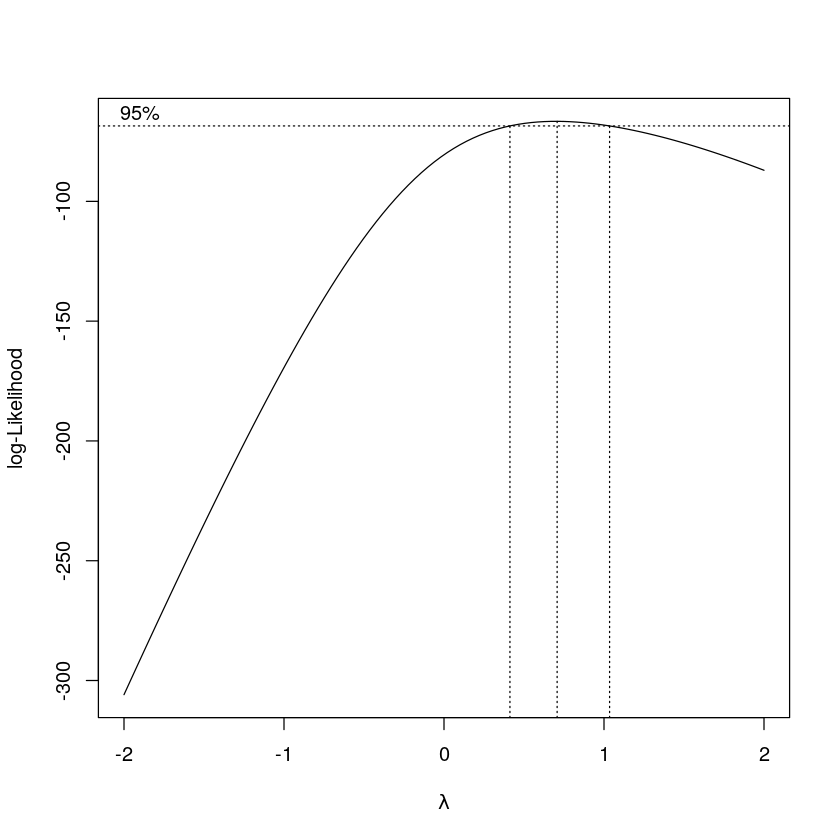

```r
y = fullset$cases_per_capita
x = fullset$value
z = fullset$GDP_per_capita
bc <- boxcox(y ~ x*z)
(lambda <- bc$x[which.max(bc$y)])
```

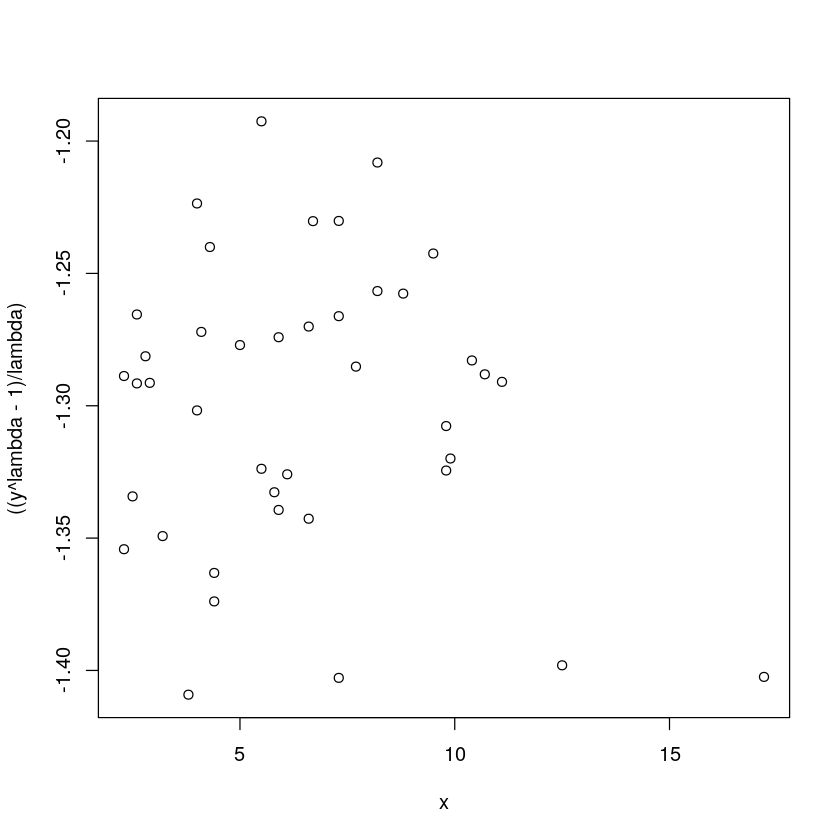

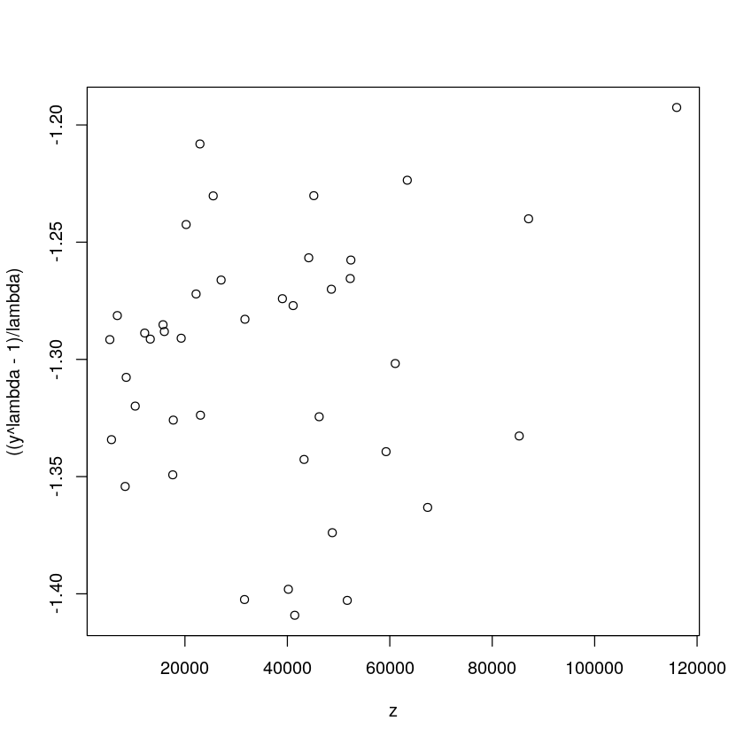

```r
plot(((y^lambda-1)/lambda)~ x*z)
```

```r
ceptmod =  lm(((y^lambda-1)/lambda) ~ x*z)
summary(ceptmod)
 aov(((y^lambda-1)/lambda) ~ x*z)
```

```
Call:
lm(formula = ((y^lambda - 1)/lambda) ~ x * z)

Residuals:
      Min        1Q    Median        3Q       Max
-0.121890 -0.040684  0.009399  0.031790  0.094365

Coefficients:
              Estimate Std. Error t value Pr(>|t|)
(Intercept) -1.333e+00  3.452e-02 -38.611   <2e-16 ***
x            4.900e-03  5.756e-03   0.851    0.400
z            1.582e-06  1.030e-06   1.536    0.133
x:z         -2.447e-07  1.855e-07  -1.319    0.195
---
Signif. codes:  0 ‘***’ 0.001 ‘**’ 0.01 ‘*’ 0.05 ‘.’ 0.1 ‘ ’ 1

Residual standard error: 0.05428 on 37 degrees of freedom
Multiple R-squared:  0.07646,	Adjusted R-squared:  0.001573
F-statistic: 1.021 on 3 and 37 DF,  p-value: 0.3944
```

```
Call:
   aov(formula = ((y^lambda - 1)/lambda) ~ x * z)

Terms:
                         x          z        x:z  Residuals
Sum of Squares  0.00164701 0.00224881 0.00512825 0.10900674
Deg. of Freedom          1          1          1         37

Residual standard error: 0.05427825
Estimated effects may be unbalanced
```

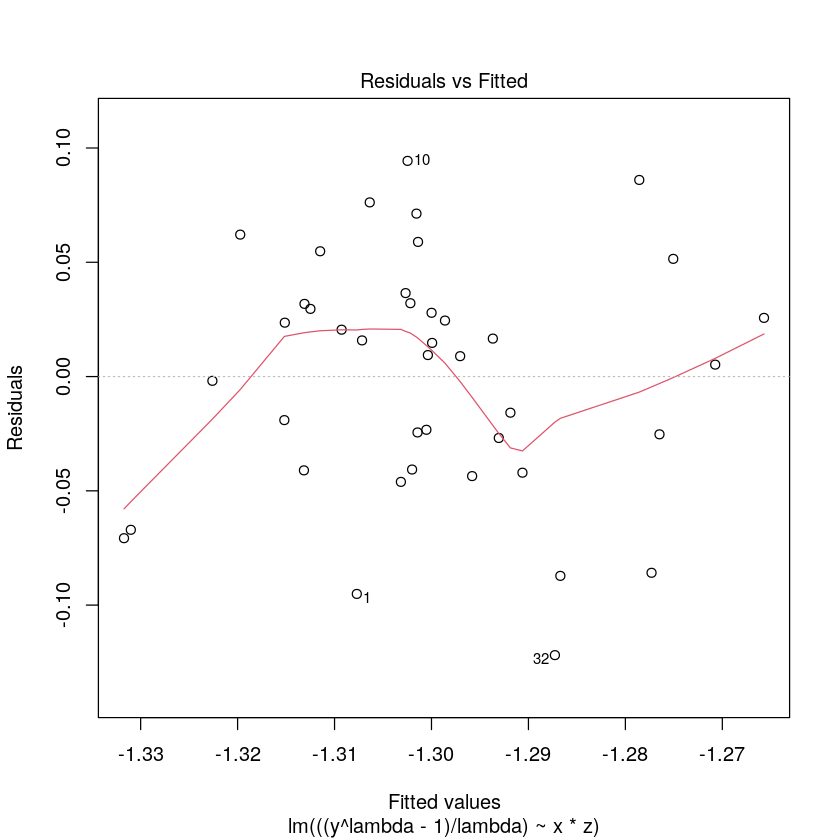

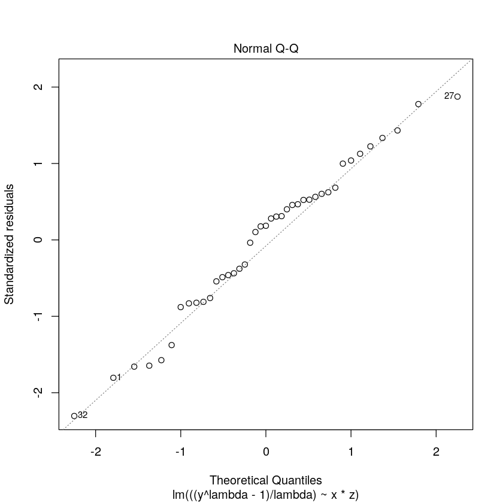

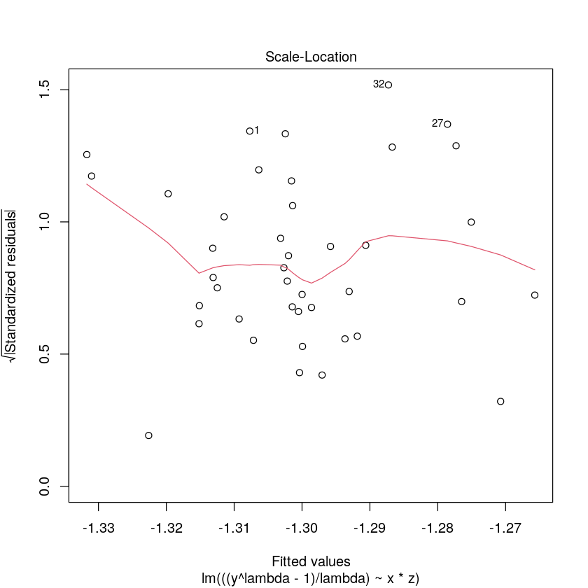

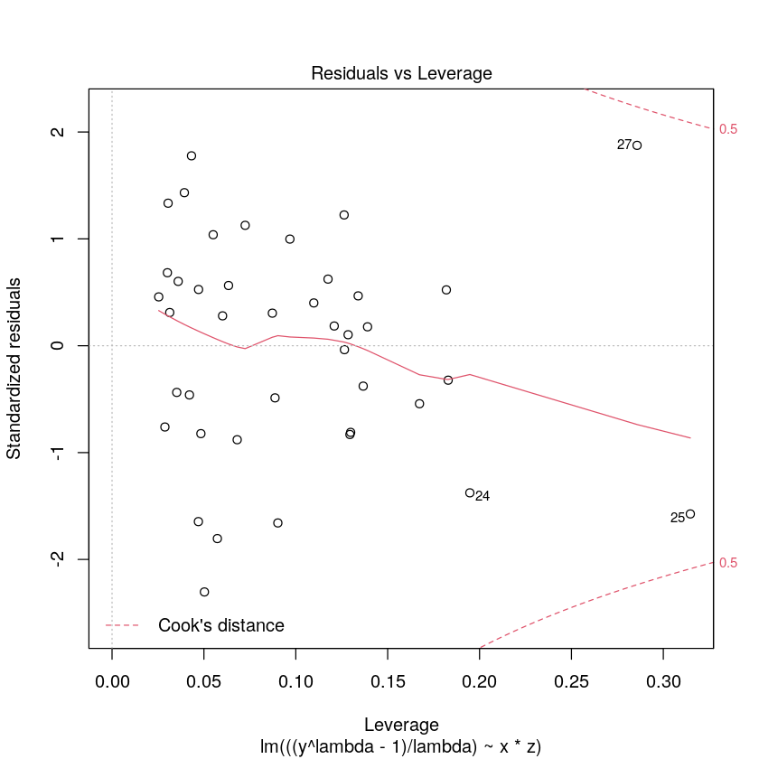

```r
plot(ceptmod)
```

```r
library(MASS)
# distribution of studentized residuals
sresid <- studres(ceptmod)
shapiro.test(sresid)
```

```
	Shapiro-Wilk normality test

data:  sresid
W = 0.97708, p-value = 0.5665
```

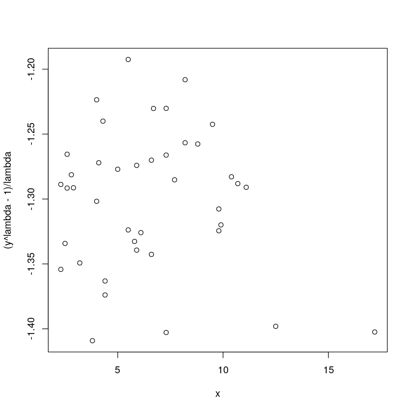

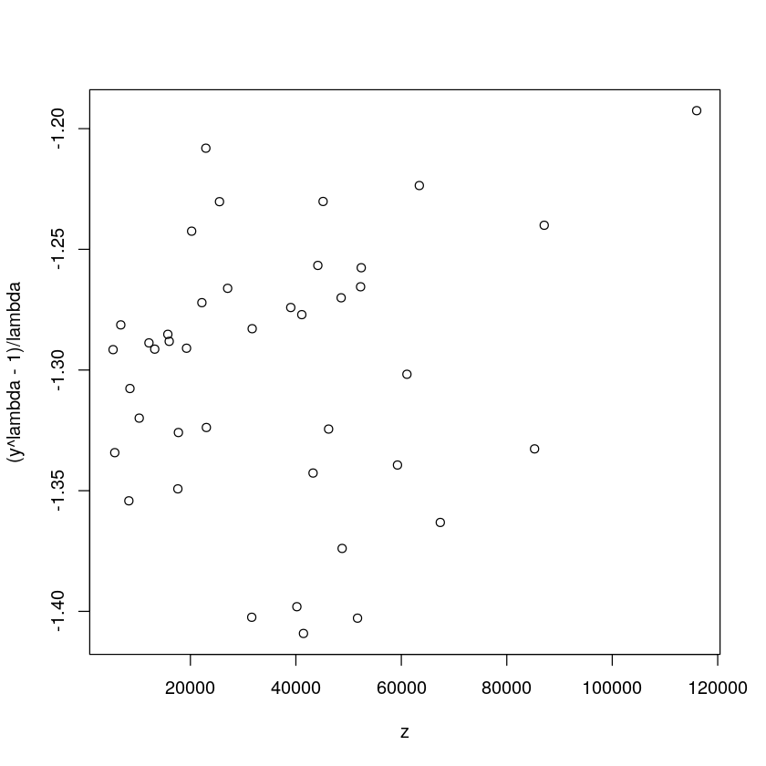

```r
y = fullset$cases_per_capita
x = fullset$value
z = fullset$GDP_per_capita
plot((y^lambda-1)/lambda~ x*z)
```

```r
summary(lm(((y^lambda-1)/lambda) ~ x))
```

```
Call:
lm(formula = ((y^lambda - 1)/lambda) ~ x)

Residuals:
      Min        1Q    Median        3Q       Max
-0.114125 -0.040199  0.003316  0.030461  0.105835

Coefficients:
             Estimate Std. Error t value Pr(>|t|)
(Intercept) -1.287557   0.019156 -67.213   <2e-16 ***
x           -0.001968   0.002649  -0.743    0.462
---
Signif. codes:  0 ‘***’ 0.001 ‘**’ 0.01 ‘*’ 0.05 ‘.’ 0.1 ‘ ’ 1

Residual standard error: 0.05463 on 39 degrees of freedom
Multiple R-squared:  0.01395,	Adjusted R-squared:  -0.01133
F-statistic: 0.5519 on 1 and 39 DF,  p-value: 0.462
```

```r
summary(lm(((y^lambda-1)/lambda) ~x + z))
```

```
Call:
lm(formula = ((y^lambda - 1)/lambda) ~ x + z)

Residuals:
     Min       1Q   Median       3Q      Max
-0.11532 -0.04422  0.01117  0.02813  0.09948

Coefficients:
              Estimate Std. Error t value Pr(>|t|)
(Intercept) -1.299e+00  2.356e-02 -55.144   <2e-16 ***
x           -1.851e-03  2.661e-03  -0.696    0.491
z            3.028e-07  3.500e-07   0.865    0.392
---
Signif. codes:  0 ‘***’ 0.001 ‘**’ 0.01 ‘*’ 0.05 ‘.’ 0.1 ‘ ’ 1

Residual standard error: 0.0548 on 38 degrees of freedom
Multiple R-squared:  0.03301,	Adjusted R-squared:  -0.01789
F-statistic: 0.6485 on 2 and 38 DF,  p-value: 0.5285
```

```r
new_model <- lm(((y^lambda-1)/lambda) ~ x*z -1)
summary(new_model)
anova(new_model)
```

```
Call:
lm(formula = ((y^lambda - 1)/lambda) ~ x * z - 1)

Residuals:
     Min       1Q   Median       3Q      Max
-0.74680 -0.24610 -0.07572  0.14810  0.42821

Coefficients:
      Estimate Std. Error t value Pr(>|t|)
x   -1.929e-01  1.665e-02 -11.587 4.88e-14 ***
z   -3.124e-05  3.684e-06  -8.479 2.71e-10 ***
x:z  5.032e-06  7.950e-07   6.330 2.01e-07 ***
---
Signif. codes:  0 ‘***’ 0.001 ‘**’ 0.01 ‘*’ 0.05 ‘.’ 0.1 ‘ ’ 1

Residual standard error: 0.3442 on 38 degrees of freedom
Multiple R-squared:  0.9352,	Adjusted R-squared:  0.9301
F-statistic: 182.7 on 3 and 38 DF,  p-value: < 2.2e-16
```

A anova: 4 × 5

|  | Df <int> | Sum Sq <dbl> | Mean Sq <dbl> | F value <dbl> | Pr(>F) <dbl> |
| --- | --- | --- | --- | --- | --- |
| x | 1 | 55.842213 | 55.8422133 | 471.44216 | 5.084394e-23 |
| z | 1 | 4.350098 | 4.3500979 | 36.72526 | 4.707961e-07 |
| x:z | 1 | 4.746534 | 4.7465337 | 40.07212 | 2.007747e-07 |
| Residuals | 38 | 4.501091 | 0.1184498 | NA | NA |

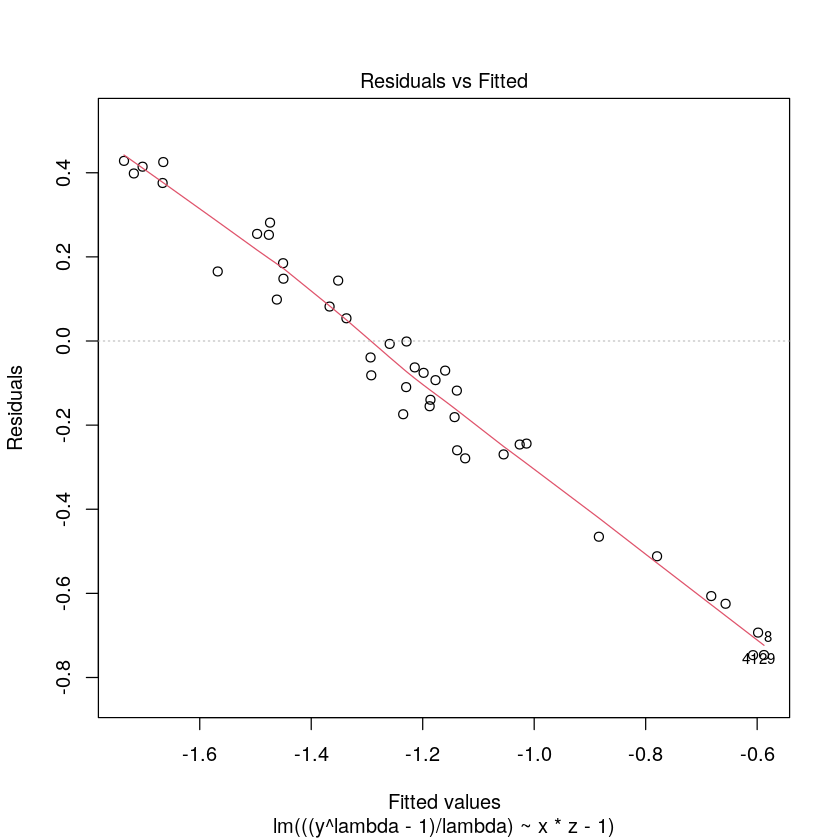

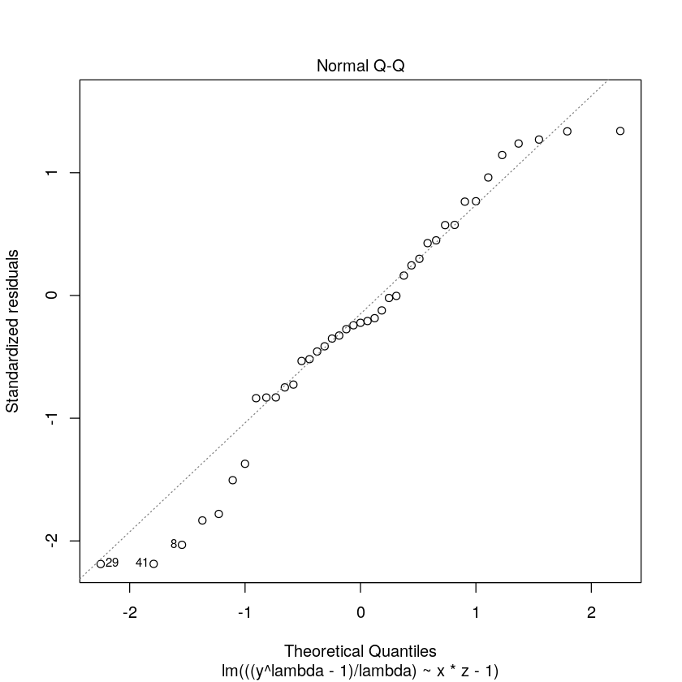

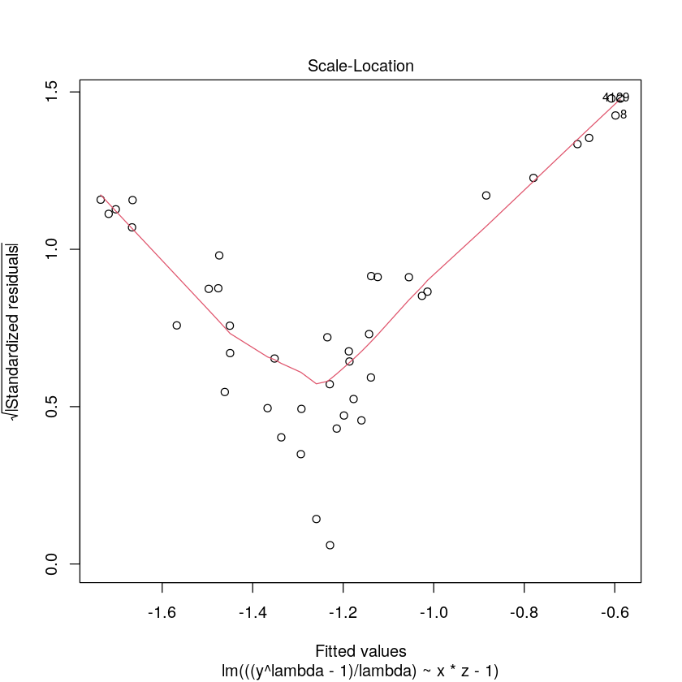

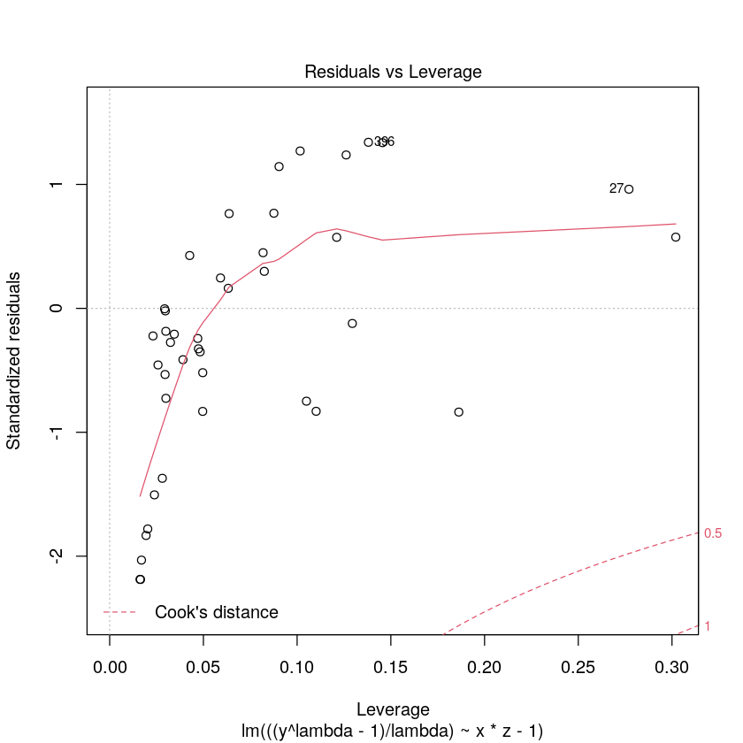

```r
plot(new_model)
```

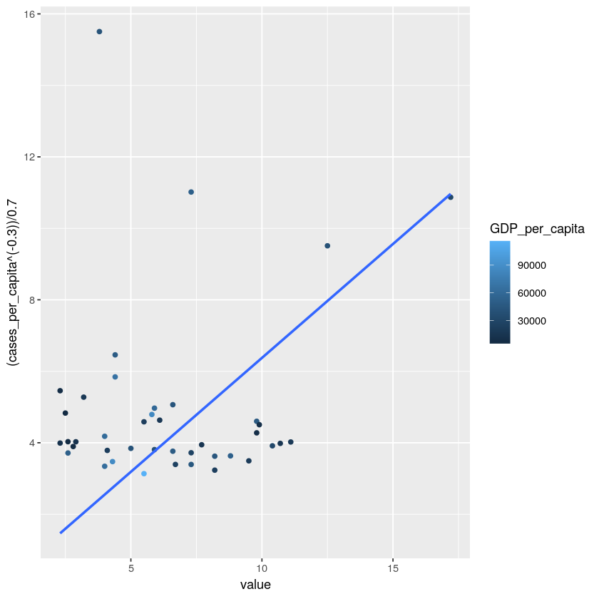

```r
z =fullset$GDP_per_capita
ggplot(fullset,aes(y=(cases_per_capita^(-.3))/.7,x=value,color=GDP_per_capita))+geom_point()+stat_smooth(method="lm", formula = y~x -1, se=FALSE)
```

### Testing out region

```r
head(fullset)
```

A data.frame: 6 × 14

|  | iso3c <chr> | GDP <dbl> | code <fct> | cases <dbl> | deaths <dbl> | country <chr> | year <chr> | value <dbl> | Population <dbl> | deaths_per_capita <dbl> | cases_per_capita <dbl> | GDP_per_capita <dbl> | Region <dbl> | fatality <dbl> |
| --- | --- | --- | --- | --- | --- | --- | --- | --- | --- | --- | --- | --- | --- | --- |
| 1 | AUS | 1.327836e+12 | AU | 28350 | 909 | Australia | 2019 | 7.3 | 25687041 | 3.538749e-05 | 0.001103669 | 51692.843 | 1 | 0.03206349 |
| 2 | AUT | 4.332585e+11 | AT | 353080 | 6256 | Austria | 2019 | 6.6 | 8917205 | 7.015651e-04 | 0.039595366 | 48586.801 | 1 | 0.01771836 |
| 3 | BEL | 5.218613e+11 | BE | 646437 | 19684 | Belgium | 2019 | 7.3 | 11555997 | 1.703358e-03 | 0.055939526 | 45159.348 | 1 | 0.03044999 |
| 4 | BRA | 1.444733e+12 | BR | 7504833 | 191570 | Brazil | 2013 | 2.8 | 212559409 | 9.012539e-04 | 0.035306990 | 6796.845 | 3 | 0.02552622 |
| 5 | CAN | 1.644037e+12 | CA | 559064 | 15222 | Canada | 2019 | 6.6 | 38005238 | 4.005237e-04 | 0.014710183 | 43258.176 | 2 | 0.02722765 |
| 6 | CHE | 7.522480e+11 | CH | 446959 | 7425 | Switzerland | 2017 | 4.3 | 8636896 | 8.596838e-04 | 0.051749957 | 87097.036 | 1 | 0.01661226 |

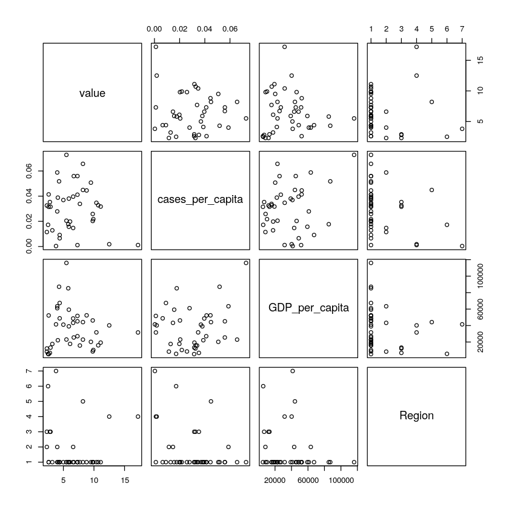

```r
plot(fullset[,c(8,11,12,13)])
```

```r
reg = lm(cases_per_capita~value*Region, data = fullset)
summary(reg)
```

```
Call:
lm(formula = cases_per_capita ~ value * Region, data = fullset)

Residuals:
      Min        1Q    Median        3Q       Max
-0.032566 -0.013568 -0.001023  0.007750  0.039529

Coefficients:
               Estimate Std. Error t value Pr(>|t|)
(Intercept)   0.0330580  0.0112469   2.939  0.00564 **
value         0.0007320  0.0016511   0.443  0.66011
Region       -0.0011386  0.0036840  -0.309  0.75900
value:Region -0.0004923  0.0005364  -0.918  0.36470
---
Signif. codes:  0 ‘***’ 0.001 ‘**’ 0.01 ‘*’ 0.05 ‘.’ 0.1 ‘ ’ 1

Residual standard error: 0.01765 on 37 degrees of freedom
Multiple R-squared:  0.1352,	Adjusted R-squared:  0.06505
F-statistic: 1.928 on 3 and 37 DF,  p-value: 0.142
```

```r
REG = lm(cases_per_capita~GDP*Region, data = fullset)
summary(REG)
```

```
Call:
lm(formula = cases_per_capita ~ GDP * Region, data = fullset)

Residuals:
      Min        1Q    Median        3Q       Max
-0.033381 -0.013153  0.000216  0.008913  0.041500

Coefficients:
              Estimate Std. Error t value Pr(>|t|)
(Intercept)  3.405e-02  4.886e-03   6.969 3.11e-08 ***
GDP          4.129e-15  3.423e-15   1.206    0.235
Region      -2.975e-03  2.208e-03  -1.347    0.186
GDP:Region  -1.565e-15  1.633e-15  -0.958    0.344
---
Signif. codes:  0 ‘***’ 0.001 ‘**’ 0.01 ‘*’ 0.05 ‘.’ 0.1 ‘ ’ 1

Residual standard error: 0.01743 on 37 degrees of freedom
Multiple R-squared:  0.1558,	Adjusted R-squared:  0.08731
F-statistic: 2.276 on 3 and 37 DF,  p-value: 0.09588
```

```r
regionmod = lm(cases_per_capita~ value*GDP + value*Region, data = fullset)
summary(regionmod)
```

```
Call:
lm(formula = cases_per_capita ~ value * GDP + value * Region,
    data = fullset)

Residuals:
      Min        1Q    Median        3Q       Max
-0.031713 -0.013902 -0.000122  0.008781  0.039907

Coefficients:
               Estimate Std. Error t value Pr(>|t|)
(Intercept)   2.690e-02  1.095e-02   2.458   0.0191 *
value         1.613e-03  1.604e-03   1.006   0.3213
GDP           5.706e-15  2.325e-15   2.454   0.0193 *
Region       -2.024e-03  3.541e-03  -0.572   0.5712
value:GDP    -1.057e-15  4.959e-16  -2.131   0.0402 *
value:Region -1.599e-04  5.457e-04  -0.293   0.7712
---
Signif. codes:  0 ‘***’ 0.001 ‘**’ 0.01 ‘*’ 0.05 ‘.’ 0.1 ‘ ’ 1

Residual standard error: 0.01671 on 35 degrees of freedom
Multiple R-squared:  0.2664,	Adjusted R-squared:  0.1617
F-statistic: 2.543 on 5 and 35 DF,  p-value: 0.04592
```

```r
regionmod = lm((cases_per_capita^lambda-1)/lambda ~ value*GDP + value*Region , data = fullset)
summary(regionmod)
```

```
Call:
lm(formula = (cases_per_capita^lambda - 1)/lambda ~ value * GDP +
    value * Region, data = fullset)

Residuals:
      Min        1Q    Median        3Q       Max
-0.110974 -0.037024  0.005921  0.026231  0.098775

Coefficients:
               Estimate Std. Error t value Pr(>|t|)
(Intercept)  -1.308e+00  3.180e-02 -41.137   <2e-16 ***
value         4.927e-03  4.659e-03   1.058   0.2975
GDP           1.624e-14  6.756e-15   2.404   0.0216 *
Region       -5.892e-03  1.029e-02  -0.573   0.5705
value:GDP    -3.050e-15  1.441e-15  -2.117   0.0414 *
value:Region -7.925e-04  1.586e-03  -0.500   0.6203
---
Signif. codes:  0 ‘***’ 0.001 ‘**’ 0.01 ‘*’ 0.05 ‘.’ 0.1 ‘ ’ 1

Residual standard error: 0.04855 on 35 degrees of freedom
Multiple R-squared:  0.3011,	Adjusted R-squared:  0.2013
F-statistic: 3.016 on 5 and 35 DF,  p-value: 0.02289
```

## Sensitivity Analysis

For the model contain deaths per capita, we can see significant clear deviation from the ideal horizontal band, indicating that the variance of errors is not equal. The normal qq plot, does indicate that the variance of errors follows a relatively normal distribution.

The same can be said for the model containing cases per capita, which puts our rejecting of the null hypothesis into question.

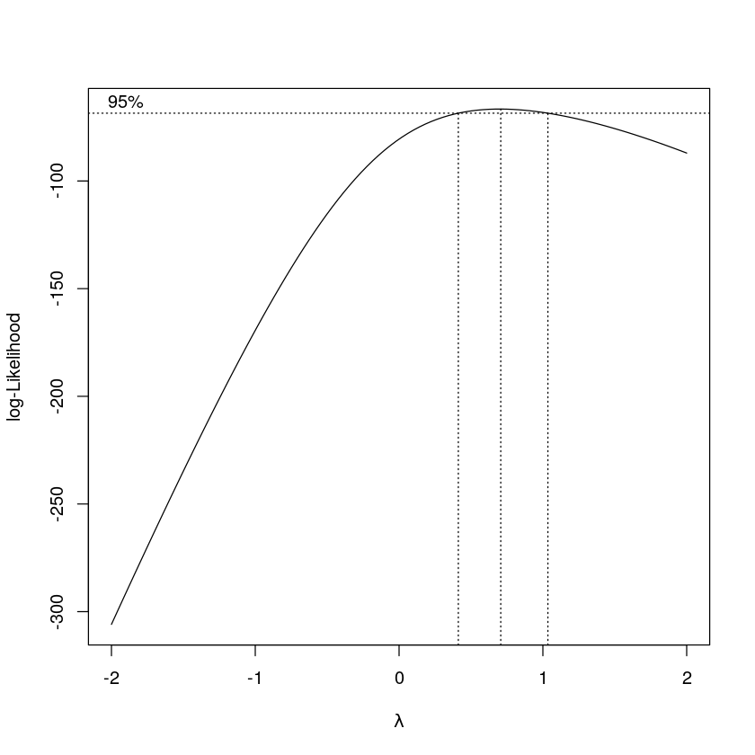

```r
boxcox(casemodel)$c
```